Penela Cleaned Parcels Analysis

# Introduction

Nina.space has been provided with a list of parcels that have been cleaned. One shape file (['ESF_Flopen_2018'](https://drive.google.com/open?id=1ZRvwdXvk-y1XTT-Nd1URzbzU3nJ5wNj3)) was inspected, where (as per Penela Municipalities): parcels that were cleaned, will have the date of cleaning in "DAT_FIM" field. One such parcel is show in the image below, where the cleaning date was in 27-Jul-2018. Note the image below, shows the cleaned parcel in dark blue and original FGC plan in red. Please note the "DAT_FIM" field:

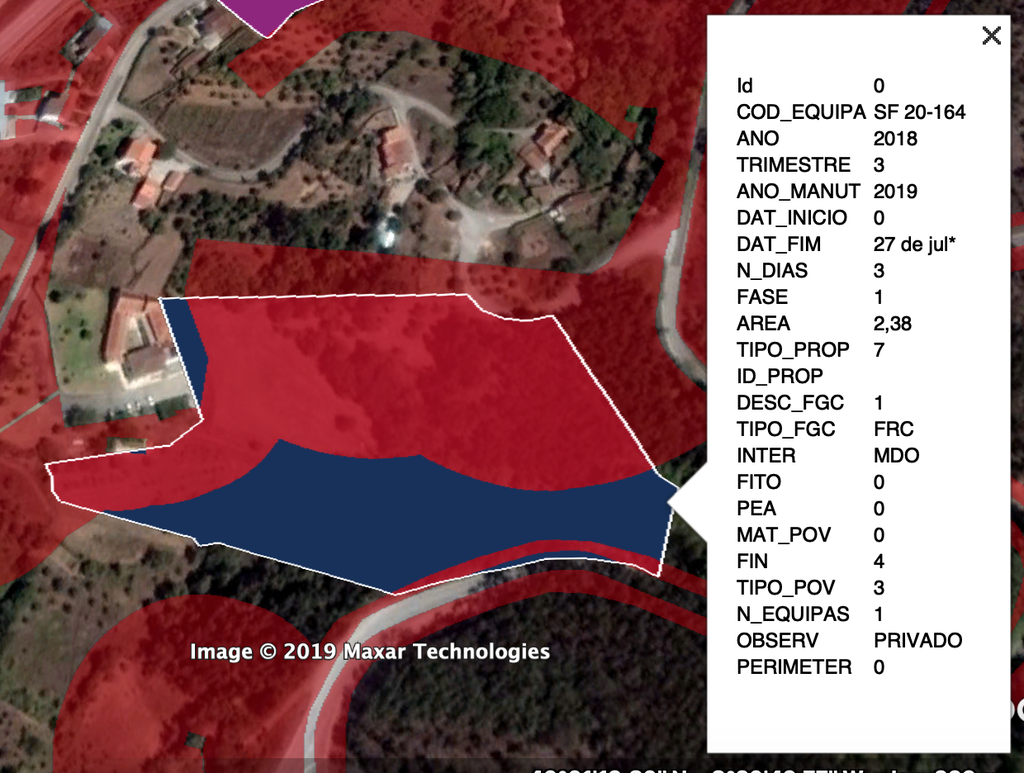

As such, the following will measure the NDVI before (June 2018) and after (August 2018), to see if there's any discernible change.

## Initialisation

Import packages

```python
import gdal
import os
import json
import rasterio.plot
import numpy as np
import pandas as pd
import geopandas as gpd
import rasterio as rio
import rasterio.mask as mask
import matplotlib.pyplot as plt
import pandas as pd
from rasterio.plot import show
from rasterio.plot import show_hist

import warnings
warnings.filterwarnings('ignore')
```

Set working directory

```python
os.chdir('../Github/DataProjects/Penela NDVI Analysis')
```

Create functions that will be used later:

- Read JP2
- Convert to Tiff
- Convert CRS to EPSG:4326

```python
def jp2tiff_wgs84 (path, dsn):
    #Use GDAL to open JP2 image
    jp2=gdal.Open(path)

    #Convert JP2 to Tiff AND convert CRS
    gdal.Warp(dsn, jp2, dstSRS='EPSG:4326')
```

Create function to:

- Read Tiff
- Crop tiff based on polygon

```python
def readandcrop (path, poly):
    #Open connection with Tiff file
    with rio.open(path) as src:

        #Read cropped version of tiff based on Polygon
        raster_image, raster_transform = mask.mask(dataset=src,shapes=[poly],crop=True)

    #Return cropped image and its transform
    return raster_image, raster_transform
```

# Shape file: Read, Convert CRS and JSON

As per image above, the shape file that was cleaned on 27/07/2018 will be read, its Coordinate Reference System (CRS) converted into WGS84. Then the specific parcel in question will be extracted and plotted (as a visual confirmation):

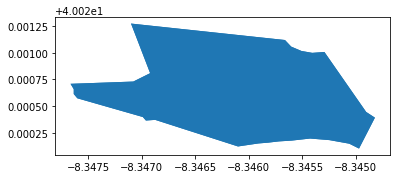

```python
#Read Shape file
cleaned_parcels=gpd.read_file('shape files/ESF_Flopen_2018.shp')

#Convert to WGS84 (EPSG: 4326)
cleaned_wgs84=cleaned_parcels.to_crs({'init':'epsg:4326'})

#Extract the parcel in question
cleaned_one_poly=cleaned_wgs84[cleaned_wgs84['DAT_FIM']=='27 de jul*']

#Convert to JSON, which will be used later
cleaned_json=json.loads(cleaned_one_poly.to_json())['features'][0]['geometry']

#Plot for visual validation
cleaned_one_poly.plot()
```

# Read and Convert Rasters

As per above, the following will read JP2, convert to TIFF and convert its CRS to EPSG: 4326 (WGS84). The files that will be read and converted, are Sentinel 2, specifically Band 4 & 8 (needed to calculate NDVI). The files are dated for:

- 2018/06/19
- 2018/08/18

```python
jp2tiff_wgs84("2018-06/T29TNE_20180619T112111_B04.jp2","B04_1806.tiff")
jp2tiff_wgs84("2018-06/T29TNE_20180619T112111_B08.jp2","B08_1806.tiff")
jp2tiff_wgs84("2018-08/T29TNE_20180818T112111_B04.jp2","B04_1808.tiff")
jp2tiff_wgs84("2018-08/T29TNE_20180818T112111_B08.jp2","B08_1808.tiff")
```

# Read Tiff and Crop to Polygon's Extent

```python
b4_06_raster, b4_06_transform=readandcrop("B04_1806.tiff",cleaned_json)
b8_06_raster, b8_06_transform=readandcrop("B08_1806.tiff",cleaned_json)
b4_08_raster, b4_08_transform=readandcrop("B04_1808.tiff",cleaned_json)
b8_08_raster, b8_08_transform=readandcrop("B08_1808.tiff",cleaned_json)
```

# Calculate NDVI

Calculate NDVI as follows:

$$NDVI=\frac{Band8 - Band4}{Band8 + Band4}$$

```python
ndvi_06=(b8_06_raster - b4_06_raster)/(b8_06_raster + b4_06_raster)
ndvi_08=(b8_08_raster - b4_08_raster)/(b8_08_raster + b4_08_raster)
```

# Plot NDVI for June and August 2018

First we'll inspect visually if there's discernible difference before and after the presumed "cleaning" of the FGC

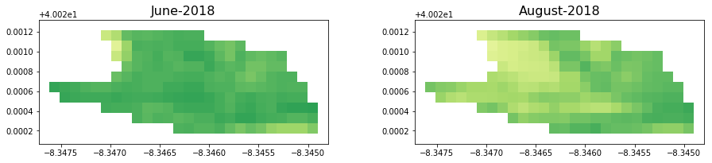

```python
#Setup canvas
fig, (ax1, ax2)=plt.subplots(1,2, figsize=(15,15))

#Plot NDVI for June
show(ndvi_06,
     ax=ax1,
     cmap='RdYlGn',
     vmin=-1,
     vmax=1,
     extent=rio.plot.plotting_extent(b4_06_raster, b4_06_transform),
     transform=b4_06_transform)

ax1.set_title('June-2018', fontsize=16);

#Plot NDVI for August
show(ndvi_08[0],
     ax=ax2,
     cmap='RdYlGn',
     vmin=-1,
     vmax=1,
     extent=rio.plot.plotting_extent(b4_06_raster, b4_06_transform),
     transform=b4_06_transform)
ax2.set_title('August-2018', fontsize=16);

#Increase space between plots
plt.subplots_adjust(wspace = 0.3)
```

It can be seen from the above that August had a considerable decrease in NDVI as a whole. But a more formal approach is taken below:

# NDVI Histogram Plot (With Mean)

Below it can be seen that August's mean NDVI dropped considerably, approx 27%. Furthermore, it can be seen that is less concentrated and more spread out.

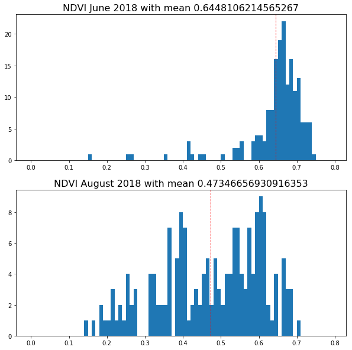

```python
fig, (ax1, ax2)=plt.subplots(2,1, figsize=(10,10))

#Plot histo for June
ax1.hist(ndvi_06.ravel(), bins=np.arange(0.0, 0.8, 0.01));
ax1.set_title('NDVI June 2018 with mean {}'.format(np.nanmean(ndvi_06)), fontsize=16);
ax1.axvline(x=np.nanmean(ndvi_06),
            color='r',
            linestyle='dashed',
            linewidth=1)

#Plot histo for June
ax2.hist(ndvi_08.ravel(), bins=np.arange(0.0, 0.8, 0.01));
ax2.set_title('NDVI August 2018 with mean {}'.format(np.nanmean(ndvi_08)), fontsize=16);
ax2.axvline(x=np.nanmean(ndvi_08),
            color='r',
            linestyle='dashed',
            linewidth=1)
```